# The impact of media on US election

# Introduction

It is undoubted that the media have played an important role in politics, due to the freedom of the press in the US. Also, voters need information to make educated decisions.

However, whether the media can really influence the result of US election deserves a think-through.

This is a data story about the impact of media on US election. To be more specific, it is going to figure out if there exists a correlation between media and voting behaviors in 2012 US election.

This report is based on the exploratory data analysis (EDA) of survey responses from the 2016 election from ANES (see https://electionstudies.org/).

### packages

```r
library(tidyverse)
library(haven)
library(devtools)
```

```r
library(RColorBrewer)
library(DT)
library(ggplot2)
library(corrplot)
```

### import data

```r
data <- read_sav("anes_timeseries_2016.sav")
```

# Background

### Recall of 2012 Presidential voting result

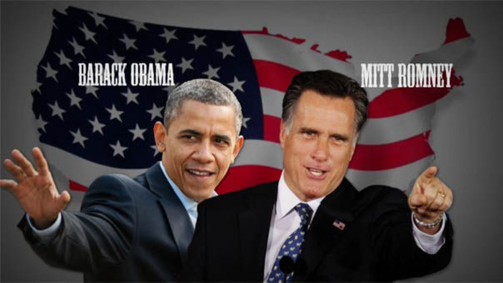

```r
voting <- table(data$V161006)
names(voting)[] <- c('Refused','Dont Know', 'Inap', 'Barack Obama', 'Mitt Romney', 'Other SPECIFY', 'Did not Vote')
voting
```

```
##       Refused     Dont Know          Inap  Barack Obama   Mitt Romney
##            47            13          1153          1728          1268
## Other SPECIFY  Did not Vote
##            58             3
```

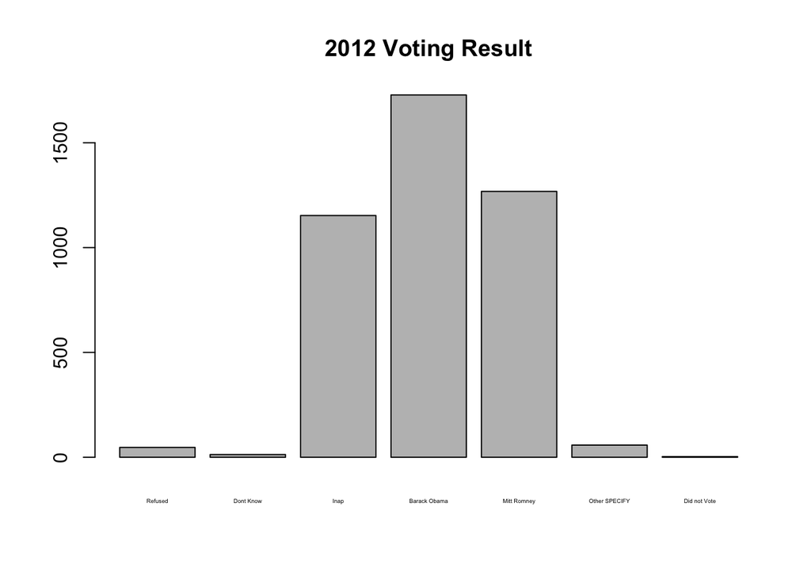

```r
barplot(voting, main = '2012 Voting Result', cex.names=0.3)
```

From the bar plot, we can see that Barack Obama received the most votes of 1728 and Mitt Romney received the next of 1268. Thus, I am going to focus on the voting behaviors towards Obama - democratic candidate and Romney - republican candidate.

# Scientific Questions

The impact of media will be analyzed from 3 perspectives - the specific TV program, the weekly frequency, and the attention level.

## Question1: Does the voting behaviors and the specific TV program people watching have a correlation?

Let’s first take a look at the media sources from which people have heard anything about the presidential campaign.

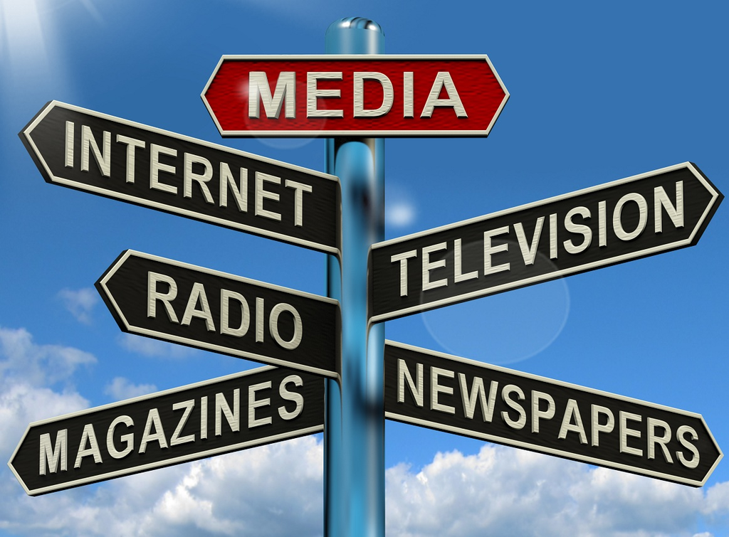

```r
TVNews=sum(data$V161363a==1)
Newspapers=sum(data$V161363b==1)
TVTalkShows=sum(data$V161363c==1)
Internet=sum(data$V161363d==1)
RadioNews=sum(data$V161363e==1)
NotHeard=sum(data$V161363f==1)
media <- c(TVNews,Newspapers,TVTalkShows,Internet,RadioNews,NotHeard)
names(media) <-c('TVNews','Newspapers','TVTalkShows','Internet','RadioNews','NotHeard')
media
```

```
##      TVNews  Newspapers TVTalkShows    Internet   RadioNews    NotHeard
##        3591        2078        2623        2609        2290          47
```

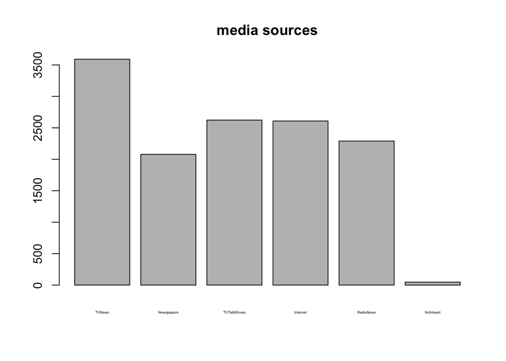

```r
barplot(media, main = 'media sources', cex.names=0.3)
```

From the bar plot, we can see that TV news programs is the most popular social media for people to learn about the presidential campaign.

Thus, I am going to find out if the specific Television news program would influence voting behaviors.

Let’s take the TV program 20/20 (program1) and TV program Primer Impacto (program2) as an example.

[figure not shown]

```r
program1 <- table(data$V161006, data$V161364)
colnames(program1) <- c('Refused','Interview breakoff','INAP','Selected','Not Selected')
rownames(program1) <- c('Refused','Dont Know', 'Inap', 'Barack Obama', 'Mitt Romney', 'Other SPECIFY', 'Did not Vote')
program1
```

```
##
##                 Refused Interview breakoff INAP Selected Not Selected
##   Refused             0                  0    6       30           11
##   Dont Know           0                  0    2        6            5
##   Inap               24                  7  184      754          184
##   Barack Obama       16                  7  168     1149          388
##   Mitt Romney        19                  3   87      901          258
##   Other SPECIFY       0                  1   16       35            6
##   Did not Vote        0                  0    1        2            0
```

[figure not shown]

```r
program2 <- table(data$V161006, data$V161426)
colnames(program2) <- c('Refused','Interview breakoff','INAP','Selected','Not Selected')
rownames(program2) <- c('Refused','Dont Know', 'Inap', 'Barack Obama', 'Mitt Romney', 'Other SPECIFY', 'Did not Vote')
program2
```

```
##
##                 Refused Interview breakoff INAP Selected Not Selected
##   Refused             0                  0   44        2            1
##   Dont Know           0                  0   12        1            0
##   Inap                7                  3  973      133           37
##   Barack Obama        0                  0 1562      137           29
##   Mitt Romney         1                  0 1224       39            4
##   Other SPECIFY       0                  0   56        2            0
##   Did not Vote        0                  0    3        0            0
```

By comparing the voting proportion, people who watch TV program Primer Impacto are more likely to vote for Barack Obama than people who watch TV program 20/20.

## Question2: Does the voting behavior and the weekly frequency people accessing to news have a correlation?

It is given that the number of days in a week people watch/listen/read news on any media.

```r
frequency <- table(data$V161008)
names(frequency)[] <- c('Refused', 'Dont Know', 'None', 'One', 'Two', 'Three', 'Four', 'Five', 'Six', 'Seven')
frequency
```

```
##   Refused Dont Know      None       One       Two     Three      Four      Five
##         2         2        73       187       212       287       266       641
##       Six     Seven
##       307      2293
```

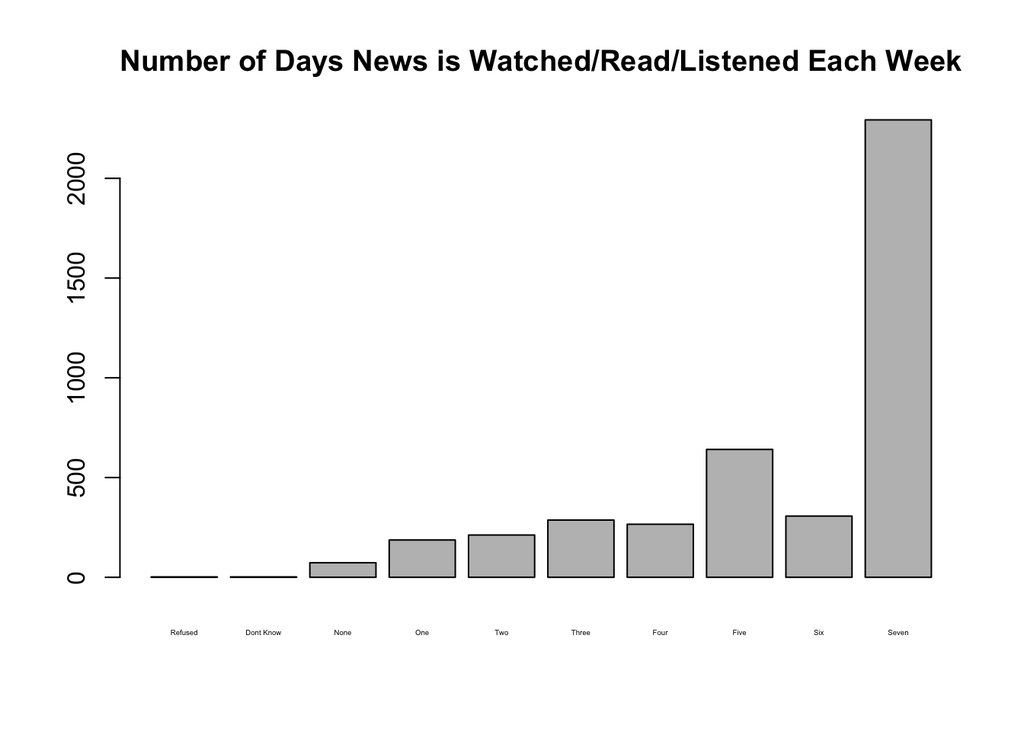

```r
barplot(frequency, main = 'Number of Days News is Watched/Read/Listened Each Week' , cex.names = 0.3)
```

Interestingly, the bar plot indicates that the majority of participants observe the news 7 days a week, with the next highest number at 5 days. Let’s jointly take a look at the voting behaviors and the weekly frequency.

```r
joint1<-table(data$V161006,data$V161008)
colnames(joint1) <- c('Refused', 'Dont Know', 'None', 'One', 'Two', 'Three', 'Four', 'Five', 'Six', 'Seven')
rownames(joint1) <- c('Refused','Dont Know', 'Inap', 'Barack Obama', 'Mitt Romney', 'Other SPECIFY', 'Did not Vote')
joint1
```

```
##
##                 Refused Dont Know None  One  Two Three Four Five  Six Seven
##   Refused             0         0    2    2    1     0    6    9    4    23
##   Dont Know           0         0    0    1    2     2    0    1    2     5
##   Inap                0         1   53   99  118   117   74  182   69   440
##   Barack Obama        2         0   11   45   44    98  115  253  119  1041
##   Mitt Romney         0         1    6   38   46    64   68  183  111   751
##   Other SPECIFY       0         0    1    2    1     6    3   13    2    30
##   Did not Vote        0         0    0    0    0     0    0    0    0     3
```

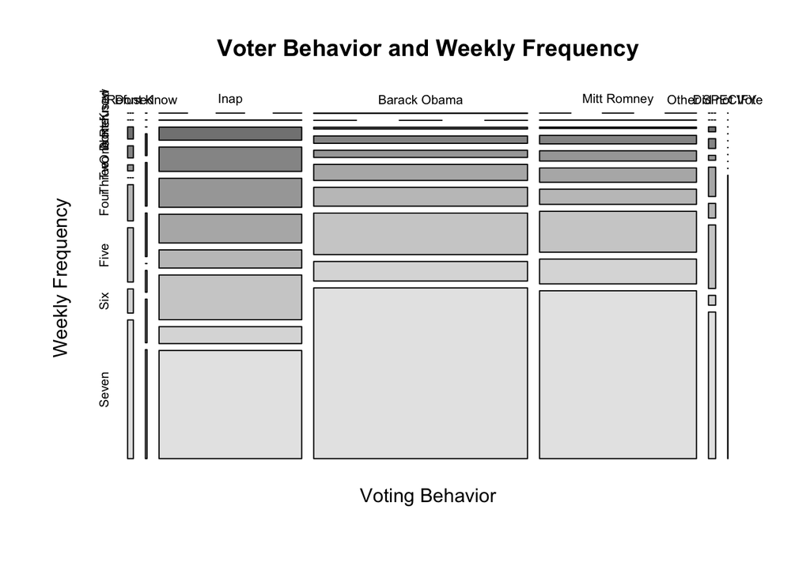

```r
mosaicplot(joint1, xlab = 'Voting Behavior', ylab = 'Weekly Frequency', main = 'Voter Behavior and Weekly Frequency', color = TRUE)
```

By the mosaic plot, we **CANNOT** see that as the weekly frequency increases or decreases, people are more or less likely to vote for Barack Obama or Mitt Romney.

Chi-square test can also be conducted to determine if there is any statistically significant interaction between these two categorical variables.

```r
chisq1 <- chisq.test(joint1)
chisq1
```

```
##
##  Pearson's Chi-squared test
##
## data:  joint1
## X-squared = 374.71, df = 54, p-value < 2.2e-16
```

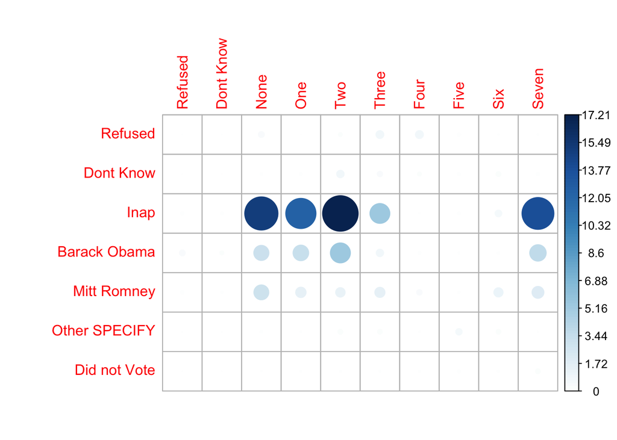

```r
contrib <- 100*chisq1$residuals^2/chisq1$statistic
corrplot(contrib, is.corr = FALSE)
```

By the balloon plot of contribution to the total chi-square score, we **CANNOT** see the strong association between the number of days and voting behaviors towards Barack Obama or Mitt Romney, due to the nearly same size of the circle.

## Question3: Does the voting behavior and the attention level people paying to news have a correlation?

It is given that the level of attention people engage in news on any media.

```r
attention <- table(data$V161009)
names(attention)[] <- c('Refused', 'Inap', 'A Great Deal', 'A Lot', 'Moderate', 'A Little', 'None at All')
attention
```

```
##      Refused         Inap A Great Deal        A Lot     Moderate     A Little
##            1           77          909         1071         1391          748
##  None at All
##           73
```

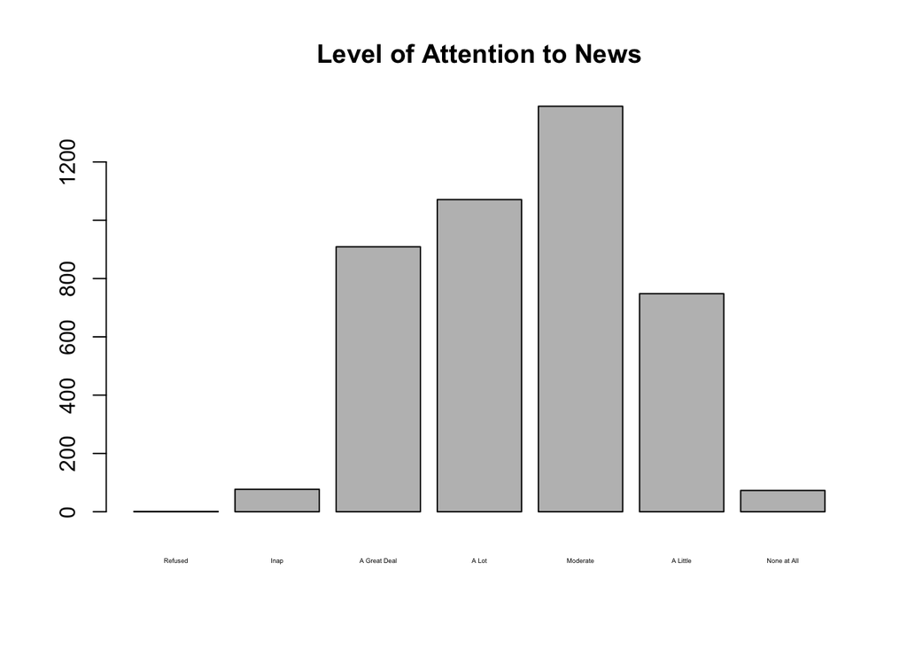

```r
barplot(attention, main = 'Level of Attention to News', cex.names= 0.3)
```

Unsurprisingly, most participants pay a a lot or a moderate amount of attention to the news.

Similarly, let’s jointly take a look at the voting behaviors and the level of attention.

```r
joint2 <- table(data$V161006,data$V161009)
colnames(joint2) <- c('Refused', 'Inap', 'A Great Deal', 'A Lot', 'Moderate', 'A Little', 'None at All')
rownames(joint2) <- c('Refused','Dont Know', 'Inap', 'Barack Obama', 'Mitt Romney', 'Other SPECIFY', 'Did not Vote')
joint2
```

```
##
##                 Refused Inap A Great Deal A Lot Moderate A Little None at All
##   Refused             1    2           12    10       16        6           0
##   Dont Know           0    0            3     1        2        7           0
##   Inap                0   54          100   182      397      366          54
##   Barack Obama        0   13          428   509      573      195          10
##   Mitt Romney         0    7          359   349      377      167           9
##   Other SPECIFY       0    1            5    19       26        7           0
##   Did not Vote        0    0            2     1        0        0           0
```

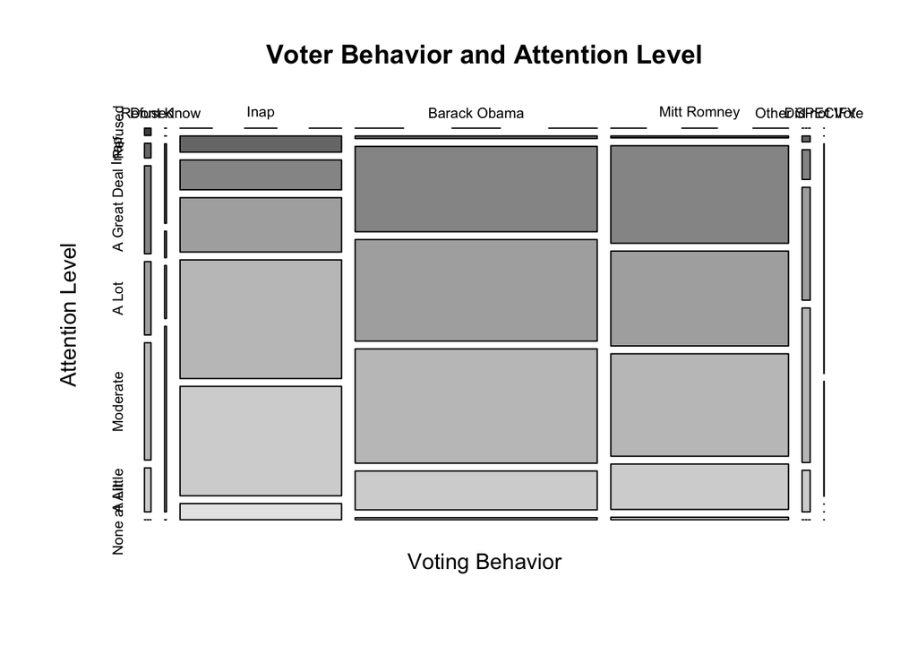

```r
mosaicplot(joint2, xlab = 'Voting Behavior', ylab = 'Attention Level', main = 'Voter Behavior and Attention Level', color = TRUE)
```

By the mosaic plot, we **CANNOT** see that as the attention level increases or decreases, people are more or less likely to vote for Barack Obama or Mitt Romney.

Similarly, chi-square test can be conducted here.

```r
chisq2 <- chisq.test(joint2)
chisq2
```

```
##
##  Pearson's Chi-squared test
##
## data:  joint2
## X-squared = 647.23, df = 36, p-value < 2.2e-16
```

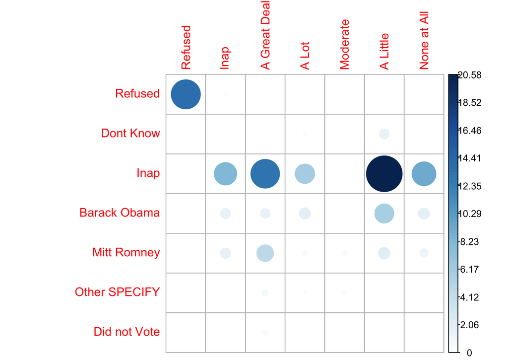

```r
contrib <- 100*chisq2$residuals^2/chisq2$statistic
corrplot(contrib, is.corr = FALSE)
```

# Conclusion and expansion

It is true that the voting behaviors is mainly based on people’s subjective choice, but this report shows that the media would exert some influence on it to some extent. As a result, we cannot negate the impact of media on US election.